# INFS3202/7202 Lab 4: Designing UI’s with CSS Frameworks

Welcome to Lab 4. You’ve been learning a lot about server-side web development and working with the Django Framework. Great job on your progress! This week, we’re focusing on HTML and the Bootstrap 5 CSS Framework.

It’s time to elevate the visual appeal and functionality of the Resume Builder SaaS you’re developing in the Labs. A professional look and seamless operation across various devices, including mobiles and tablets, is crucial for the success of any modern SaaS. Bootstrap 5 comes to our aid with its array of responsive design features and components. It’s designed to help developers create websites that are not only visually appealing but also highly functional and accessible. This framework will simplify the process of making your Resume Builder SaaS both attractive and user-friendly.

In this Lab, we’ll focus on developing essential screens for the Resume Builder SaaS using Bootstrap 5, ensuring that your project not only looks professional but also functions seamlessly across different devices.

In this Lab you will build the following screen/pages:

- **The Landing Page**: Users will first see your Landing Page. You need to make a good first impression and really highlight your features.
- **The Subscriber Admin Management Panel**: A vital interface for managing user subscriptions.
- **The Sign-up Form**: An intuitive and straightforward form that allows end-users to join your Resume Builder platform.

While the Resume Builder SaaS will require additional screens, these three (3) are pivotal to learning Bootstrap. They encompass design elements and styles that you’ll be able to reuse, making your development process more efficient.

**Tip**

This lab is strategically designed to assist you with your first assessment item - The Design Document. As part of this assessment, you will need to create HTML mockups. Working on these screens/pages will provide you with a solid foundation for your mockups, helping you to effectively design of your entire SaaS.

Please note that it is not Mandatory that you use Bootstrap in your Design Document Assessment Item or for your Project. You can use any other CSS framework such as Tailwind CSS or Daisy UI and even custom CSS is allowed. You are **not allowed** to use commercial or open-source pre-built templates and themes.

## The Benefits of Using Bootstrap 5

Using Bootstrap 5 for your Resume Builder SaaS comes with several advantages that streamline development and enhance the user experience:

- **Faster Development**: Bootstrap’s pre-designed components allow for rapid UI construction, saving you time.
- **Responsiveness**: Easily create sites that look great on any device, from phones to desktops.
- **Accessibility**: Bootstrap 5 emphasizes accessibility features, making your site more user-friendly for people with disabilities.
- **Customizable**: Tailor Bootstrap’s components to fit the unique style of your Resume Builder.
- **Consistency**: Ensures a uniform look across different web browsers and devices.
- **Community Support**: Access a wide community for support, resources, and inspiration.
- **Documentation**: Benefit from comprehensive and easy-to-understand documentation.

**Note**

When we talk about responsiveness in web design, we’re focusing on how a website adjusts and changes to offer the best viewing experience across a range of devices, from the smallest smartphones to large desktop monitors. Bootstrap 5 excels in this area by using a flexible grid system, fluid containers, and media queries.

## Feel Free to Design and Customize Your Screens

- **This Is a Design Activity**: The primary goal is to learn how to effectively use Bootstrap 5 to implement your vision. The steps and code samples are starting points, not fixed rules.
- **Customization Is Encouraged**: You’re encouraged to modify the designs to fit your style or the specific needs of your project.
- **Think About the User Experience and Usability**: As you design and customize your screens, always keep the end user in mind. Think about how many steps it will take to perform a task and whether your instructions and labeling are clear.
- **Be Creative**: Use this opportunity to express your creativity and design skills. Whether it’s a unique layout, an innovative use of components, or a special animation, your design choices can make your project stand out.

Remember, the provided steps and code in this Lab are meant to inspire and guide you.

## Getting Started with Bootstrap 5

To get started with a Bootstrap 5 project in Visual Studio Code (VS Code), follow these steps to create your initial setup:

1. **Make a New Folder**: Create a new folder anywhere on your computer where you’d like to store your project. You can name it anything you like, for example, `Lab4_BootstrapUI`. You can use your local laptop/computer or work on your UQCloud Zone.
2. **Open VSCode**: Launch Visual Studio Code and open the folder you just created by going to `File` > `Open Folder` and selecting your new folder.
3. **Create a New File**: Within VS Code, right-click in the Explorer pane on the left side, select `New File`, and name it `bootstrap_starter.html`.
4. **Add HTML Boilerplate**: Copy the started code below into the `bootstrap_starter.html` file:

```html
<!doctype html>
<html lang="en">
  <head>
    <meta charset="utf-8">
    <meta name="viewport" content="width=device-width, initial-scale=1">
    <title>Bootstrap ScratchPad</title>
    <!-- This is the main stylesheet for Bootstrap. It includes all the CSS necessary for Bootstrap's components and utilities to work. -->
    <link href="https://cdn.jsdelivr.net/npm/bootstrap@5.3.3/dist/css/bootstrap.min.css" rel="stylesheet" integrity="sha384-QWTKZyjpPEjISv5WaRU9OFeRpok6YctnYmDr5pNlyT2bRjXh0JMhjY6hW+ALEwIH" crossorigin="anonymous">
    <!-- Include Bootstrap Icons -->
    <!-- This link imports the Bootstrap Icons library, which provides a wide range of SVG icons for use in your projects. -->
    <link rel="stylesheet" href="https://cdn.jsdelivr.net/npm/bootstrap-icons@1.11.3/font/bootstrap-icons.min.css">
  </head>
  <body>
    <h1>Welcome, to the Bootstrap Starter File!</h1>
    <!-- This script includes all of Bootstrap's JavaScript-based components and behaviors, such as modal windows, dropdowns, and tooltips.  -->
    <script src="https://cdn.jsdelivr.net/npm/bootstrap@5.3.3/dist/js/bootstrap.bundle.min.js" integrity="sha384-YvpcrYf0tY3lHB60NNkmXc5s9fDVZLESaAA55NDzOxhy9GkcIdslK1eN7N6jIeHz" crossorigin="anonymous"></script>
  </body>
</html>
```

**Tip**

Anything in HTML between a `<!--` and `-->` is a comment.

The line `<meta name="viewport" content="width=device-width, initial-scale=1.0">` is crucial for responsive design. It tells the browser to match the width of the page to the width of the device screen, which means your page will look good on all devices. The `initial-scale=1.0` part sets the initial zoom level when the page is first loaded by the browser.

A Content Delivery Network (CDN) is a network of servers distributed globally, designed to deliver content to users more quickly and efficiently. Using Bootstrap 5 via a CDN is highly beneficial for prototyping because it allows you to include Bootstrap’s CSS and JavaScript files into your project without downloading and hosting them on your server. This speeds up the development process and ensures you’re using the most up-to-date version of Bootstrap when you are making Mockups.

5. **Preview the Web page**: After saving, you can open the file in any web browser by right-clicking the file and selecting “Open with” followed by your preferred browser. Alternatively, you can drag and drop the file into the browser window. VS Code offers extensions like “Live Preview” from Microsoft that can help you preview your HTML file inside VS Code without leaving the editor and opening a Web browser. This is particularly useful when developing especially when you are designing User Interfaces. You are encouraged to install the “Live Preview” VS Code extension.

## Understanding Containers

Now, let’s enhance your page by adding a container around your heading. Bootstrap’s container class is used to center your content horizontally and apply some padding.

**Tip**

All the example code included in this lab can be downloaded from the Blackboard Course site.

The `bootstrap_containers.html` file has the HTML for the `container` examples.

- **Standard Container (`container`)**: This centers your content and applies a max-width depending on the size of the viewport. It’s useful when you want your website content to align in the center with padding around it, making it visually appealing on larger screens. Here’s how you can wrap your heading in a container. Remember to Preview in a browser after you make the change. Try resizing the browser window.

```html
<div class="container">
    <h1>Hello, I'm styled by Bootstrap in a container!</h1>
    <div class="border p-3 mt-3">
        <p>This is a paragraph inside a div with a border and padding. Bootstrap's utility classes make it easy to add styles like borders and spacing.</p>
        <button class="btn btn-primary">Click Me!</button>
    </div>
</div>
```

- **Fluid Container (`container-fluid`)**: This makes the container span the full width of the viewport, allowing your content to occupy all available horizontal space. It’s useful for designs that require full-width elements, such as headers or background images that stretch edge to edge regardless of the device screen size. If you want your container to span the full width of the viewport for all screen sizes, you can use a fluid container. This is done by using the `container-fluid` class. Here’s how you use it. Remember to Preview in a browser after you make the change. Try resizing the browser window.

```html
<div class="container-fluid">
    <h1>Hello, I'm styled by Bootstrap in a fluid container!</h1>
    <div class="border p-3 mt-3">
        <p>This is a paragraph inside a div with a border and padding. Bootstrap's utility classes make it easy to add styles like borders and spacing.</p>
        <button class="btn btn-primary">Click Me!</button>
    </div>
</div>
```

## Exploring Bootstrap

As you continue to develop your skills with Bootstrap 5, a crucial step is familiarizing yourself with the extensive range of components and utilities it offers. A great way to do this is by reviewing into the Bootstrap documentation.

1. **Visit the Bootstrap Documentation**: Start by going to the [Bootstrap Layout Containers documentation](https://getbootstrap.com/docs/5.3/layout/containers/). This page will give you a solid understanding of how containers work, which is fundamental to creating responsive designs.
2. **Explore Components**: From the documentation page, take a look at the side panel listing various Bootstrap components. I encourage you to scroll through this list to get a sense of what’s available. Bootstrap provides a wide array of components, from basic ones like buttons and cards to more complex components such as carousels and modals.
3. **Review Key Components**: Specifically, take some time to review the following:
   - **Typography**: Learn how Bootstrap can help you manage your text’s appearance, including headings, paragraphs, and more, ensuring readability across devices.
   - **Buttons**: Buttons are a staple of user interaction. Discover how to use Bootstrap’s button styles for different purposes and actions.
   - **Cards**: Cards are versatile components for displaying content and actions on a single topic. They can hold a variety of content, including images, text, list groups, and more.
4. **Using the Copy Feature**: As you explore these components, you’ll notice a “Copy” button in the top right corner of code snippets throughout the Bootstrap documentation. This handy feature allows you to quickly copy the HTML markup with all the necessary Bootstrap classes.
5. **Experiment in Your Starter File**: After copying a code snippet, switch back to your `bootstrap_starter.html` file in your code editor. Find a suitable place in your HTML structure, paste the copied code, and save the file. Now, when you refresh your page in the browser, you’ll see the new component in action.

This process of exploring the documentation, reviewing components, and integrating them into your project is an excellent way to learn Bootstrap. It enables you to see immediate results and understand how different components can be customized and combined to create engaging layouts.

Here is an example with a variety of components (from the `bootstrap_components.html` file):

```html
<!doctype html>
<html lang="en">
  <head>
    <meta charset="utf-8">
    <meta name="viewport" content="width=device-width, initial-scale=1">
    <title>Bootstrap ScratchPad</title>
    <!-- This is the main stylesheet for Bootstrap. It includes all the CSS necessary for Bootstrap's components and utilities to work. -->
    <link href="https://cdn.jsdelivr.net/npm/bootstrap@5.3.3/dist/css/bootstrap.min.css" rel="stylesheet" integrity="sha384-QWTKZyjpPEjISv5WaRU9OFeRpok6YctnYmDr5pNlyT2bRjXh0JMhjY6hW+ALEwIH" crossorigin="anonymous">
    <!-- Include Bootstrap Icons -->
    <!-- This link imports the Bootstrap Icons library, which provides a wide range of SVG icons for use in your projects. -->
    <link rel="stylesheet" href="https://cdn.jsdelivr.net/npm/bootstrap-icons@1.11.3/font/bootstrap-icons.min.css">
  </head>
  <body>
    <div class="container border p-3 mt-3">
        <!-- Typography Example -->
        <h1>Heading H1</h1>

        <h2>Heading H2</h2>
        <h3>Heading H3</h3>
        <p>This paragraph demonstrates Bootstrap's default typography. It's designed for excellent readability across devices.</p>

        <p class="text-center">This text will be centered.</p>

        <hr>

        <!-- Buttons Example -->
        <h2>Buttons</h2>
        <button type="button" class="btn btn-primary">Primary Button</button>
        <button type="button" class="btn btn-secondary">Secondary Button</button>
        <hr>

        <!-- Card Example -->
        <h2>Card Component</h2>
        <div class="card" style="width: 18rem;">
            <img src="https://dummyimage.com/150" class="card-img-top" alt="Describe the image">
            <div class="card-body">
                <h5 class="card-title">Card Title</h5>
                <p class="card-text">Some quick example text to build on the card title and make up the bulk of the card's content.</p>
                <a href="#" class="btn btn-primary">Go somewhere</a>
            </div>
        </div>
    </div>
    <!-- This script includes all of Bootstrap's JavaScript-based components and behaviors, such as modal windows, dropdowns, and tooltips.  -->
    <script src="https://cdn.jsdelivr.net/npm/bootstrap@5.3.3/dist/js/bootstrap.bundle.min.js" integrity="sha384-YvpcrYf0tY3lHB60NNkmXc5s9fDVZLESaAA55NDzOxhy9GkcIdslK1eN7N6jIeHz" crossorigin="anonymous"></script>
  </body>
</html>
```

One of the powerful features of Bootstrap is the ability to combine multiple classes on a single HTML element. This allows you to apply various styles and achieve more complex designs without writing any additional CSS. Classes are added within the class attribute, separated by spaces.

For example, to style a button with Bootstrap, you might use the `.btn` class to apply general button styling and `.btn-primary` to color the button with the primary color defined in Bootstrap’s color scheme.

## Using Icons

Bootstrap 5 introduces a dedicated icons library, Bootstrap Icons, which is a separate component from the core Bootstrap framework. This means you can use these icons independently of Bootstrap’s CSS and JavaScript components, but they integrate seamlessly when used together. The icons are SVG (Scalable Vector Graphics), ensuring they look crisp and clear at any size and can be easily styled with CSS.

Bootstrap Icons offer a wide range of icons suitable for various applications, from social media icons to tools and devices, making it easy to add visual elements to your Bootstrap-powered projects. You can browse the full list of icons and their corresponding class names in the [Bootstrap Icons documentation](https://icons.getbootstrap.com/).

To use Bootstrap Icons, you need to include the Bootstrap Icons library in your project. This can be done by adding a link to the Bootstrap Icons stylesheet in your HTML file’s `<head>` section:

```html
<link rel="stylesheet" href="https://cdn.jsdelivr.net/npm/bootstrap-icons@1.3.0/font/bootstrap-icons.css">
```

Once the stylesheet is linked, you can use any of the icons by adding an `<i>` or `<span>` element with a class name corresponding to the desired icon. The class name follows the format `bi-{icon-name}`, where `{icon-name}` is the name of the icon you want to use.

Here are a few examples showing how to include different icons in your HTML. Since Bootstrap Icons are SVGs, you can easily style them using CSS. For example, you can change the color or size of an icon by applying CSS styles directly to the `<i>` or `<span>` element (from the `bootstrap_icons.html` file).

```html
<!doctype html>
<html lang="en">
  <head>
    <meta charset="utf-8">
    <meta name="viewport" content="width=device-width, initial-scale=1">
    <title>Bootstrap ScratchPad</title>
    <!-- This is the main stylesheet for Bootstrap. It includes all the CSS necessary for Bootstrap's components and utilities to work. -->
    <link href="https://cdn.jsdelivr.net/npm/bootstrap@5.3.3/dist/css/bootstrap.min.css" rel="stylesheet" integrity="sha384-QWTKZyjpPEjISv5WaRU9OFeRpok6YctnYmDr5pNlyT2bRjXh0JMhjY6hW+ALEwIH" crossorigin="anonymous">
    <!-- Include Bootstrap Icons -->
    <!-- This link imports the Bootstrap Icons library, which provides a wide range of SVG icons for use in your projects. -->
    <link rel="stylesheet" href="https://cdn.jsdelivr.net/npm/bootstrap-icons@1.11.3/font/bootstrap-icons.min.css">
  </head>
  <body>
    <div class="container border p-3 mt-3">
        <h1>Bootstrap Icons</h1>

        <i class="bi bi-search"></i>

        <i class="bi bi-envelope"></i>

        <i class="bi bi-gear"></i>

        <i class="bi bi-heart"></i>

        <i class="bi bi-heart" style="color: red;"></i>

        <i class="bi bi-heart" style="font-size: 2rem;"></i>
    </div>
    <!-- This script includes all of Bootstrap's JavaScript-based components and behaviors, such as modal windows, dropdowns, and tooltips.  -->
    <script src="https://cdn.jsdelivr.net/npm/bootstrap@5.3.3/dist/js/bootstrap.bundle.min.js" integrity="sha384-YvpcrYf0tY3lHB60NNkmXc5s9fDVZLESaAA55NDzOxhy9GkcIdslK1eN7N6jIeHz" crossorigin="anonymous"></script>
  </body>
</html>
```

## Building the Landing Page

The landing page is often the first point of contact between your product or service and potential users or customers. It plays a pivotal role in shaping the visitor’s first impression, conveying essential information, and guiding them towards taking a desired action, such as signing up.

The Landing page requires:

- A Navigation Bar (or Nav bar) with links to Home and Login
- A Hero display
- A list of product features
- A button to Sign-Up
- A footer

Use the Bootstrap Starter HTML file and select components from the Bootstrap documentation to create the landing page. You may also find the [Bootstrap Snippets](https://getbootstrap.com/docs/5.3/examples/) useful. Remember that your version of this page can be unique.

Here is an example of what the landing page could look like:

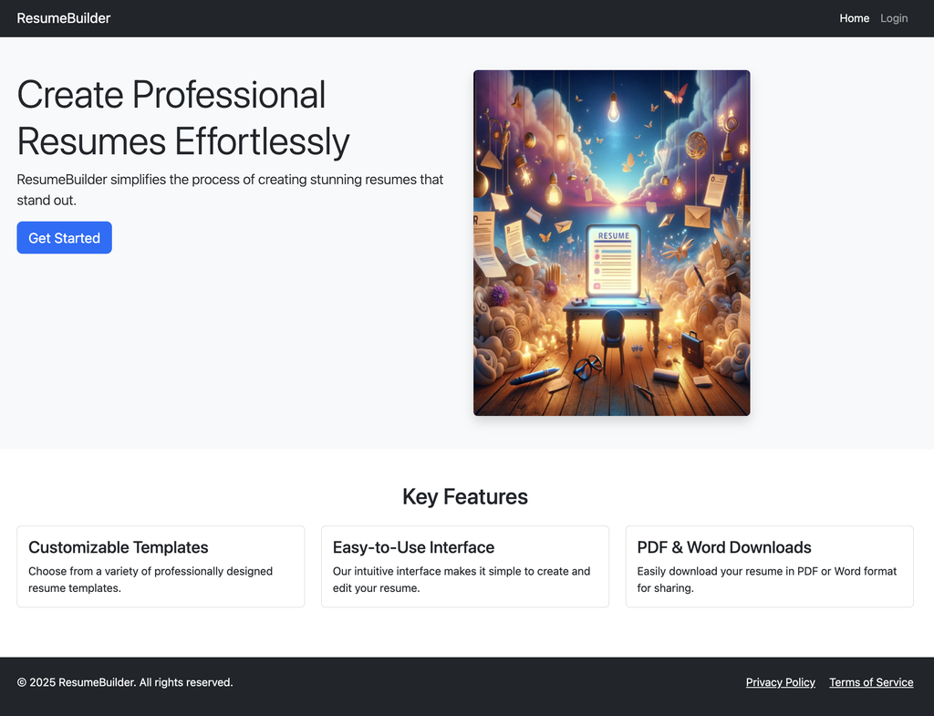

Here is what that landing page looks like when resized for a smaller mobile device screen. As you can see in Bootstrap the navigation bar automatically becomes a `hamburger` menu that can expand on a smaller screen. The columns also stack one below each other.

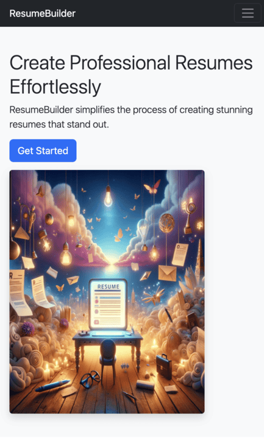

The `screens/landing_page.html` file contains the code:

```html
<!doctype html>
<html lang="en">
  <head>
    <meta charset="utf-8">
    <meta name="viewport" content="width=device-width, initial-scale=1">
    <title>Bootstrap ScratchPad</title>
    <!-- This is the main stylesheet for Bootstrap. It includes all the CSS necessary for Bootstrap's components and utilities to work. -->
    <link href="https://cdn.jsdelivr.net/npm/bootstrap@5.3.3/dist/css/bootstrap.min.css" rel="stylesheet" integrity="sha384-QWTKZyjpPEjISv5WaRU9OFeRpok6YctnYmDr5pNlyT2bRjXh0JMhjY6hW+ALEwIH" crossorigin="anonymous">
    <!-- Include Bootstrap Icons -->
    <!-- This link imports the Bootstrap Icons library, which provides a wide range of SVG icons for use in your projects. -->
    <link rel="stylesheet" href="https://cdn.jsdelivr.net/npm/bootstrap-icons@1.11.3/font/bootstrap-icons.min.css">
  </head>
  <body>
    <header>
        <nav class="navbar navbar-expand-lg navbar-dark bg-dark">
            <div class="container">
                <a class="navbar-brand" href="#">ResumeBuilder</a>
                <button class="navbar-toggler" type="button" data-bs-toggle="collapse" data-bs-target="#navbarNav" aria-controls="navbarNav" aria-expanded="false" aria-label="Toggle navigation">
                    <span class="navbar-toggler-icon"></span>
                </button>
                <div class="collapse navbar-collapse" id="navbarNav">
                    <ul class="navbar-nav ms-auto">
                        <li class="nav-item">
                            <a class="nav-link active" href="#">Home</a>
                        </li>
                        <li class="nav-item">
                            <a class="nav-link" href="#">Login</a>
                        </li>
                    </ul>
                </div>
            </div>
        </nav>
    </header>

    <main>
        <section class="py-5 bg-light">
            <div class="container">
                <div class="row">
                    <div class="col-lg-6">
                        <h1 class="display-4">Create Professional Resumes Effortlessly</h1>
                        <p class="lead">ResumeBuilder simplifies the process of creating stunning resumes that stand out.</p>
                        <a href="#" class="btn btn-primary btn-lg mb-3 mb-lg-0">Get Started</a>
                    </div>
                    <div class="col-lg-6">
                        <img src="resumebuilder.png" alt="ResumeBuilder Screenshot" class="img-fluid rounded shadow">
                    </div>
                </div>
            </div>
        </section>

        <section class="py-5">
            <div class="container">
                <h2 class="text-center mb-4">Key Features</h2>
                <div class="row">
                    <div class="col-lg-4 mb-4">
                        <div class="card">
                            <div class="card-body">
                                <h4 class="card-title">Customizable Templates</h4>
                                <p class="card-text">Choose from a variety of professionally designed resume templates.</p>
                            </div>
                        </div>
                    </div>
                    <div class="col-lg-4 mb-4">
                        <div class="card">
                            <div class="card-body">
                                <h4 class="card-title">Easy-to-Use Interface</h4>
                                <p class="card-text">Our intuitive interface makes it simple to create and edit your resume.</p>
                            </div>
                        </div>
                    </div>
                    <div class="col-lg-4 mb-4">
                        <div class="card">
                            <div class="card-body">
                                <h4 class="card-title">PDF & Word Downloads</h4>
                                <p class="card-text">Easily download your resume in PDF or Word format for sharing.</p>
                            </div>
                        </div>
                    </div>
                </div>
            </div>
        </section>
    </main>

    <footer class="bg-dark text-light py-4">
        <div class="container">
            <div class="row">
                <div class="col-md-6">
                    <p>&copy; 2025 ResumeBuilder. All rights reserved.</p>
                </div>
                <div class="col-md-6 text-md-end">
                    <a href="#" class="text-light me-3">Privacy Policy</a>
                    <a href="#" class="text-light">Terms of Service</a>
                </div>
            </div>
        </div>
    </footer>
    <!-- This script includes all of Bootstrap's JavaScript-based components and behaviors, such as modal windows, dropdowns, and tooltips.  -->
    <script src="https://cdn.jsdelivr.net/npm/bootstrap@5.3.3/dist/js/bootstrap.bundle.min.js" integrity="sha384-YvpcrYf0tY3lHB60NNkmXc5s9fDVZLESaAA55NDzOxhy9GkcIdslK1eN7N6jIeHz" crossorigin="anonymous"></script>
  </body>
</html>
```

## Building the Admin User Management Page

The “Admin User Management Page” is a critical component of any web application or platform that requires user accounts. It serves as the control center for administrators to manage user information, permissions, and roles efficiently.

The Admin User Management Page requires:

- A Navigation Bar (or Nav bar) with User Management and Logout links
- A search bar (to search for users)
- A table with users and the ability to add new users, edit users or delete users
- Pagination (we’ll have many users and will need a way to move between pages of returned users)

Here is an example of what the Admin User Management Page could look like:

[figure not shown]

The `screens/admin_page.html` file contains the code:

```html
<!doctype html>
<html lang="en">
  <head>
    <meta charset="utf-8">
    <meta name="viewport" content="width=device-width, initial-scale=1">
    <title>Bootstrap ScratchPad</title>
    <!-- This is the main stylesheet for Bootstrap. It includes all the CSS necessary for Bootstrap's components and utilities to work. -->
    <link href="https://cdn.jsdelivr.net/npm/bootstrap@5.3.3/dist/css/bootstrap.min.css" rel="stylesheet" integrity="sha384-QWTKZyjpPEjISv5WaRU9OFeRpok6YctnYmDr5pNlyT2bRjXh0JMhjY6hW+ALEwIH" crossorigin="anonymous">
    <!-- Include Bootstrap Icons -->
    <!-- This link imports the Bootstrap Icons library, which provides a wide range of SVG icons for use in your projects. -->
    <link rel="stylesheet" href="https://cdn.jsdelivr.net/npm/bootstrap-icons@1.11.3/font/bootstrap-icons.min.css">
  </head>
  <body>
    <header>
        <nav class="navbar navbar-expand-lg navbar-dark bg-dark">
            <div class="container">
                <a class="navbar-brand" href="#">ResumeBuilder</a>
                <button class="navbar-toggler" type="button" data-bs-toggle="collapse" data-bs-target="#navbarNav" aria-controls="navbarNav" aria-expanded="false" aria-label="Toggle navigation">
                    <span class="navbar-toggler-icon"></span>
                </button>
                <div class="collapse navbar-collapse" id="navbarNav">
                    <ul class="navbar-nav ms-auto">
                        <li class="nav-item">
                            <a class="nav-link" href="#">Home</a>
                        </li>
                        <li class="nav-item">
                          <a class="nav-link active active" href="#">User Management</a>
                        </li>
                        <li class="nav-item">
                          <a class="nav-link" href="#">Logout</a>
                        </li>
                    </ul>
                </div>
            </div>
        </nav>
    </header>

    <main>
      <section class="py-5">
          <div class="container">
              <div class="d-flex justify-content-between align-items-center mb-4">
                  <h2>User Management</h2>
              </div>
              <div class="row mb-4">
                  <div class="col-md-6 mb-3 mb-lg-0">
                      <div class="input-group">
                          <input type="text" class="form-control" placeholder="Enter your search..." name="search">
                          <button class="btn btn-primary" type="button">Search</button>
                      </div>
                  </div>
                  <div class="col-md-6 text-md-end">
                      <button class="btn btn-primary">Add New User</button>
                  </div>
              </div>
              <table class="table table-striped">
                  <thead>
                      <tr>
                          <th>User ID</th>
                          <th>Username</th>
                          <th>First Name</th>
                          <th>Last Name</th>
                          <th>Email</th>
                          <th>Actions</th>
                      </tr>
                  </thead>
                  <tbody>
                      <tr>
                          <td>1</td>
                          <td>lchen</td>
                          <td>Liz</td>
                          <td>Chen</td>
                          <td>lchen@example.com</td>
                          <td>
                              <button class="btn btn-sm btn-primary me-2 mb-1"><i class="bi bi-eye-fill"></i></button>
                              <button class="btn btn-sm btn-info me-2 mb-1"><i class="bi bi-pencil-fill"></i></button>
                              <button class="btn btn-sm btn-warning mb-1"><i class="bi bi-dash-circle-fill"></i></button>
                          </td>
                      </tr>
                      <tr>
                          <td>2</td>
                          <td>janesmith</td>
                          <td>Jane</td>
                          <td>Smith</td>
                          <td>janesmith@example.com</td>
                          <td>
                              <button class="btn btn-sm btn-primary me-2 mb-1"><i class="bi bi-eye-fill"></i></button>
                              <button class="btn btn-sm btn-info me-2 mb-1"><i class="bi bi-pencil-fill"></i></button>
                              <button class="btn btn-sm btn-warning mb-1"><i class="bi bi-dash-circle-fill"></i></button>
                          </td>
                      </tr>
                  </tbody>
              </table>
              <nav aria-label="Page navigation">
                  <ul class="pagination justify-content-center">
                      <li class="page-item disabled">
                          <a class="page-link" href="#" tabindex="-1" aria-disabled="true">Previous</a>
                      </li>
                      <li class="page-item"><a class="page-link" href="#">1</a></li>
                      <li class="page-item"><a class="page-link" href="#">2</a></li>
                      <li class="page-item"><a class="page-link" href="#">3</a></li>
                      <li class="page-item">
                          <a class="page-link" href="#">Next</a>
                      </li>
                  </ul>
              </nav>
          </div>
      </section>
    </main>

    <footer class="bg-dark text-light py-4">
        <div class="container">
            <div class="row">
                <div class="col-md-6">
                    <p>&copy; 2024 ResumeBuilder. All rights reserved.</p>
                </div>
                <div class="col-md-6 text-md-end">
                    <a href="#" class="text-light me-3">Privacy Policy</a>
                    <a href="#" class="text-light">Terms of Service</a>
                </div>
            </div>
        </div>
    </footer>
    <!-- This script includes all of Bootstrap's JavaScript-based components and behaviors, such as modal windows, dropdowns, and tooltips.  -->
    <script src="https://cdn.jsdelivr.net/npm/bootstrap@5.3.3/dist/js/bootstrap.bundle.min.js" integrity="sha384-YvpcrYf0tY3lHB60NNkmXc5s9fDVZLESaAA55NDzOxhy9GkcIdslK1eN7N6jIeHz" crossorigin="anonymous"></script>
  </body>
</html>
```

## Building the Sign-up Form

The Sign-up Form is the initial step in the user’s journey, where they transition from a visitor to an engaged user. Forms allow data to be collected from the user and sent to the server. In this Lab we will only concentrate on using Bootstrap to style the form.

The Sign-up form needs to collect the users username, password, first name, last name and email address and have a `Register` button.

Review the classes and components that are need to build a form here: [Bootstrap Forms Documentation](https://getbootstrap.com/docs/5.3/forms/form-control/)

**Tip**

If you have not seen the `<label>` and `<input>` tags before, please refer to the [MDN HTML documentation](https://developer.mozilla.org/en-US/docs/Web/HTML/Element/input/text).

Here is an example of what the Sign Up Form could look like:

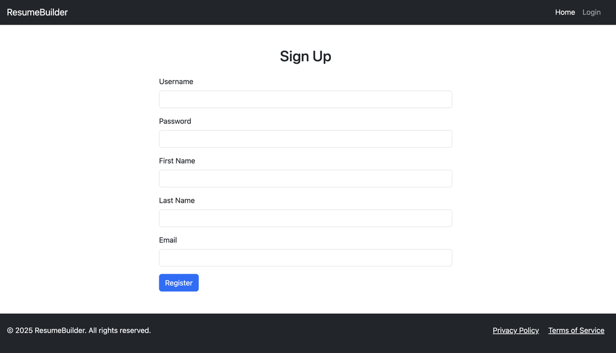

The `screens/signup_page.html` file contains the code:

```html
<!doctype html>
<html lang="en">
  <head>
    <meta charset="utf-8">
    <meta name="viewport" content="width=device-width, initial-scale=1">
    <title>Bootstrap ScratchPad</title>
    <!-- This is the main stylesheet for Bootstrap. It includes all the CSS necessary for Bootstrap's components and utilities to work. -->
    <link href="https://cdn.jsdelivr.net/npm/bootstrap@5.3.3/dist/css/bootstrap.min.css" rel="stylesheet" integrity="sha384-QWTKZyjpPEjISv5WaRU9OFeRpok6YctnYmDr5pNlyT2bRjXh0JMhjY6hW+ALEwIH" crossorigin="anonymous">
    <!-- Include Bootstrap Icons -->
    <!-- This link imports the Bootstrap Icons library, which provides a wide range of SVG icons for use in your projects. -->
    <link rel="stylesheet" href="https://cdn.jsdelivr.net/npm/bootstrap-icons@1.11.3/font/bootstrap-icons.min.css">
  </head>
  <body>
    <header>
        <nav class="navbar navbar-expand-lg navbar-dark bg-dark">
            <div class="container">
                <a class="navbar-brand" href="#">ResumeBuilder</a>
                <button class="navbar-toggler" type="button" data-bs-toggle="collapse" data-bs-target="#navbarNav" aria-controls="navbarNav" aria-expanded="false" aria-label="Toggle navigation">
                    <span class="navbar-toggler-icon"></span>
                </button>
                <div class="collapse navbar-collapse" id="navbarNav">
                    <ul class="navbar-nav ms-auto">
                        <li class="nav-item">
                            <a class="nav-link active" href="#">Home</a>
                        </li>
                        <li class="nav-item">
                            <a class="nav-link" href="#">Login</a>
                        </li>
                    </ul>
                </div>
            </div>
        </nav>
    </header>

    <main>
      <section class="py-5">
          <div class="container">
              <div class="row justify-content-center">
                  <div class="col-lg-6">
                      <h2 class="text-center mb-4">Sign Up</h2>
                      <form>
                          <div class="mb-3">
                              <label for="username" class="form-label">Username</label>
                              <input type="text" class="form-control" id="username" required>
                          </div>
                          <div class="mb-3">
                              <label for="exampleInputPassword1" class="form-label">Password</label>
                              <input type="password" class="form-control" id="exampleInputPassword1">
                            </div>
                          <div class="mb-3">
                              <label for="firstname" class="form-label">First Name</label>
                              <input type="text" class="form-control" id="firstname" required>
                          </div>
                          <div class="mb-3">
                              <label for="lastname" class="form-label">Last Name</label>
                              <input type="text" class="form-control" id="lastname" required>
                          </div>
                          <div class="mb-3">
                              <label for="email" class="form-label">Email</label>
                              <input type="email" class="form-control" id="email" required>
                          </div>
                          <button type="submit" class="btn btn-primary">Register</button>
                      </form>
                  </div>
              </div>
          </div>
      </section>
    </main>

    <footer class="bg-dark text-light py-4">
        <div class="container">
            <div class="row">
                <div class="col-md-6">
                    <p>&copy; 2025 ResumeBuilder. All rights reserved.</p>
                </div>
                <div class="col-md-6 text-md-end">
                    <a href="#" class="text-light me-3">Privacy Policy</a>
                    <a href="#" class="text-light">Terms of Service</a>
                </div>
            </div>
        </div>
    </footer>
    <!-- This script includes all of Bootstrap's JavaScript-based components and behaviors, such as modal windows, dropdowns, and tooltips.  -->
    <script src="https://cdn.jsdelivr.net/npm/bootstrap@5.3.3/dist/js/bootstrap.bundle.min.js" integrity="sha384-YvpcrYf0tY3lHB60NNkmXc5s9fDVZLESaAA55NDzOxhy9GkcIdslK1eN7N6jIeHz" crossorigin="anonymous"></script>
  </body>
</html>
```

This template gives you a robust starting point for a Register page. Notice how Bootstrap classes are used to style and layout the form, making it responsive and user-friendly.

To further refine your form, I encourage you to delve into the Bootstrap documentation specifically focused on forms. Here, you can explore different styles and components that Bootstrap offers to enhance form elements. Visit the [Bootstrap Forms Overview](https://getbootstrap.com/docs/5.3/forms/overview/) to get a comprehensive understanding of how to leverage Bootstrap to create forms that are not only functional but also aesthetically pleasing.

## Challenge - Understanding Bootstrap Utility Classes (Optional)

**Warning**

This is advanced content and optional.

Bootstrap’s utility classes are a powerful set of tools designed to enhance your web development process, allowing for rapid styling adjustments directly in your HTML markup. These classes offer a wide range of stylistic modifications, from layout and spacing to color and typography, all without writing custom CSS. Understanding and utilizing these utility classes can significantly speed up your development time and make your code more readable and maintainable.

- **Spacing Classes**: These classes are used to control margin and padding around elements. The syntax follows a pattern of `{property}{sides}-{size}` (e.g., `mt-3` for `margin-top: 1rem;`). This allows for quick adjustments directly within your HTML markup.
- **Color and Background Classes**: Quickly change the text color (`text-primary`) or background color (`bg-secondary`) of an element using these utility classes. Bootstrap includes a predefined palette that can be customized in your project’s theme.
- **Typography Classes**: Adjust font size (`fs-1` to `fs-6`), text alignment (`text-center`), font weight (`fw-bold`), and more, ensuring that your typography is consistent and responsive.
- **Border Classes**: Add or remove borders (`border`, `border-0`), control border width (`border-2`), and set border colors (`border-primary`) easily with these utility classes.

To apply utility classes, simply add them to your HTML elements as class attributes. For example, to create a responsive, center-aligned card with padding and a shadow, you might write:

```html
<div class="card mx-auto my-5 p-3 shadow" style="width: 18rem;">
    <!-- Card content goes here -->
</div>
```

In this example, `mx-auto` centers the card horizontally, `my-5` adds vertical margin, `p-3` applies padding, and `shadow` adds a subtle shadow around the card.

Here’s a more complex example:

```html
<div class="container p-5 bg-light border">
    <p class="text-center text-primary">Welcome to Bootstrap!</p>
</div>
```

In this example, the `<div>` element uses:

- `.container` for a centered fixed-width container,
- `.p-5` for padding around the content,
- `.bg-light` for a light background color,
- `.border` for a border around the element.

The `<p>` element inside it uses:

- `.text-center` to center the text,
- `.text-primary` to apply the primary theme color to the text.

This modular approach to design, where you can stack and combine different styles, makes Bootstrap incredibly flexible and powerful for web development. You can create sophisticated layouts and components by simply adding and mixing predefined classes, all without the need for custom CSS.

Dive deeper into Bootstrap’s utility classes by visiting the [official Bootstrap documentation](https://getbootstrap.com/docs/5.3/utilities/api/). Experiment with different utilities to see how they can streamline your workflow and enhance your project’s design.

Understanding and leveraging Bootstrap’s utility classes will empower you to create more visually appealing and responsive designs with less effort, making your web projects stand out.

## Challenge - Layout in Bootstrap (Optional)

**Warning**

This is advanced content and optional.

In Bootstrap, the column system is fundamental to the framework’s responsive layout capabilities. It’s built on a grid system that uses a series of containers, rows, and columns to layout and align content in a flexible and responsive manner. Here’s a breakdown of how columns work in Bootstrap:

The grid system is contained within a `.container` (fixed-width) or `.container-fluid` (full-width) class which provides the proper alignment and padding.

Rows are wrappers for columns and are declared with a `.row` class. Each row is horizontal and serves as a flex container, allowing its columns to align neatly, regardless of their individual heights.

Columns are the vertical divisions of space within a row and are created by using the `.col-{breakpoint}-{size}` class structure, where:

- `{breakpoint}` is one of Bootstrap’s predefined breakpoints (`xs`, `sm`, `md`, `lg`, `xl`, `xxl`) that corresponds to a range of screen sizes. These breakpoints allow the layout to adjust across different screen widths, like mobile phones, tablets, and desktops.
- `{size}` is the number of units you’re dividing the row into. Bootstrap’s grid system is based on 12 columns, so `{size}` can be a number from 1 to 12, indicating how many columns the div should span.

For example, `.col-md-6` means that on medium-sized screens and up, the column will span half the width of the row (6 out of 12 units).

**Column Classes**

- `.col-`: Automatically size columns based on the number of columns in a row
- `.col-auto`: Content-based sizing of columns
- `.col-{1-12}`: Explicitly define the column’s width, e.g., `.col-3` will take up 25% (3/12) of the row
- `.col-{breakpoint}-{1-12}`: Define the column’s width starting at a specific screen size, e.g., `.col-md-4` on medium screens
- `.col-{breakpoint}-auto`: Use automatic column width based on content starting at a specific screen size

You can nest rows and columns within columns by creating a new `.row` and a set of `.col-` classes inside an existing column.

Here is an example of using columns (the `bootstrap_columns.html` file):

```html
<!doctype html>
<html lang="en">
  <head>
    <meta charset="utf-8">
    <meta name="viewport" content="width=device-width, initial-scale=1">
    <title>Bootstrap ScratchPad</title>
    <!-- This is the main stylesheet for Bootstrap. It includes all the CSS necessary for Bootstrap's components and utilities to work. -->
    <link href="https://cdn.jsdelivr.net/npm/bootstrap@5.3.3/dist/css/bootstrap.min.css" rel="stylesheet" integrity="sha384-QWTKZyjpPEjISv5WaRU9OFeRpok6YctnYmDr5pNlyT2bRjXh0JMhjY6hW+ALEwIH" crossorigin="anonymous">
    <!-- Include Bootstrap Icons -->
    <!-- This link imports the Bootstrap Icons library, which provides a wide range of SVG icons for use in your projects. -->
    <link rel="stylesheet" href="https://cdn.jsdelivr.net/npm/bootstrap-icons@1.11.3/font/bootstrap-icons.min.css">
  </head>
  <body>
    <div class="container border p-3 mt-3">
        <!-- Typography Example -->
        <h1>Rows and Columns</h1>

        <div class="row">
            <div class="col-sm-6 col-lg-4 border">.col-sm-6 .col-lg-4</div>
            <div class="col-sm-6 col-lg-4 border">.col-sm-6 .col-lg-4</div>
            <div class="col-sm-6 col-lg-4 border">.col-sm-6 .col-lg-4</div>
        </div>

        <div class="row">
            <div class="col-sm-6 col-lg-4 border">.col-sm-6 .col-lg-4</div>
            <div class="col-sm-6 col-lg-4 border">.col-sm-6 .col-lg-4</div>
            <div class="col-sm-6 col-lg-4 border">.col-sm-6 .col-lg-4</div>
        </div>

    </div>
    <!-- This script includes all of Bootstrap's JavaScript-based components and behaviors, such as modal windows, dropdowns, and tooltips.  -->
    <script src="https://cdn.jsdelivr.net/npm/bootstrap@5.3.3/dist/js/bootstrap.bundle.min.js" integrity="sha384-YvpcrYf0tY3lHB60NNkmXc5s9fDVZLESaAA55NDzOxhy9GkcIdslK1eN7N6jIeHz" crossorigin="anonymous"></script>
  </body>
</html>
```

Preview the file in your Web browser. Adjust the screen. What happens to the columns?

The `div` element with the classes `col-sm-6 col-lg-4 border` is a Bootstrap column with responsive behavior that changes based on the screen size due to the presence of breakpoint-specific classes. Here’s how it behaves when the screen is resized:

- **Small Screens (`sm` breakpoint, ≥576px)**: The class `col-sm-6` applies, meaning the `div` will use half the available width of the row (`6` out of `12` columns in the grid system). So if the viewport width is equal to or greater than 576 pixels and less than 992 pixels (the `lg` breakpoint), this `div` will span 50% of the width of its parent container.
- **Large Screens (`lg` breakpoint, ≥992px)**: The class `col-lg-4` takes effect. At this point, the `div` will use one-third of the available width (`4` out of `12` columns), because 4 is one-third of 12. So for viewports that are 992 pixels in width or larger, this `div` will span approximately 33.33% of the width of its parent container.
- **Extra Small Screens (below `sm` breakpoint, <576px)**: Neither `col-sm-6` nor `col-lg-4` apply because the viewport is below the `sm` breakpoint. Bootstrap’s columns are stackable by default, so the `div` will automatically span the full width of the row, behaving like a `col-12`.
- **Between Small and Large Screens (`sm` to `lg` breakpoint, ≥576px and <992px)**: Within this range, the `col-sm-6` class is in effect, as described above.

The `border` class is not responsive and simply adds a border around the `div` regardless of the screen size.

In summary, as the screen is resized, the `div` will adjust its width accordingly: full width on extra small screens, half width on small to medium screens, and one-third width on large screens and above, ensuring a responsive layout that adapts to the viewing environment.

## Additional Resources

- [W3Schools Bootstrap 5 Site](https://www.w3schools.com/bootstrap5/index.php)
- [Bootstrap Examples and Code Snippets](https://getbootstrap.com/docs/5.3/examples/)

## Summary

Congratulations on successfully building three screens with Bootstrap! This accomplishment marks a significant step in your journey with one of the most versatile CSS frameworks. Here’s a quick recap of what you’ve achieved and a look ahead.

- **Mastered Basics**: You’ve grasped Bootstrap’s responsive design, utility classes, and components, laying a solid foundation for creating visually appealing, responsive websites.
- **Practical Application**: By building specific screens, you’ve applied Bootstrap’s components and utilities in real-world scenarios, enhancing your practical understanding and skills.
- **Responsive Design**: Each screen you’ve developed showcases your ability to create designs that adapt to various devices, ensuring a great user experience everywhere.
- **Creative Exploration**: Through customizing layouts and experimenting with Bootstrap’s features, you’ve begun to explore how much creativity the framework allows.

## In the Next Lab

In the next Lab you’ll be given time to complete your Design Document Assessment Item. Your Demonstrator will be able to support you during Lab time.

In Lab 6 you’ll learn to build your own Admin panel to manage (Create, Read, Update and Delete) ResumeBuilder subscribers. You’ll also learn to integrate Bootstrap into your Django Base template.